# R 패키지 ggplot2의 이해

Version 2014-01-18

## 1. 목적

- ggplot2는 데이터 시각화를 위한 그래픽 라이브러리로는 현재까지 가장 많이 사용되고 있음
- 명령어 형식의 ggplot2의 특징은
  - ggplot2(Grammer of Graphic)의 약자와 같이 grammer 기반의 명령어를 제공하여
  - 문장 형성을 통해 사용자는 데이터 시각화를 가능하게 함
  - 지속적인 update와
  - 커뮤니티를 통한 우스한 사례 공유가 가능함
- ggplot2의 활용 예를 통해 데이터 시각화의 컴포넌트와 실제 데이터와의 연결을 이해함

## 2. 원리 및 용어

- **ggplot** : 메인 함수로 데이터 셋과 표현할 데이터 변수명을 정의함
- **geoms** : 실제 어떤 데이터 시각화를 할지 정의하는 기하학적 객체
  - geom_point(), geom_bar(), geom_density(), geom_line(), geom_area()
- **aes** : aesthetics (미학적)
  - 형태, 투명도, 색상, 채우기, 라인의 형태 등을 정의
- **scales** : 데이터가 어떻게 표현될지를 정의
  - 연속형, 이산형, log 등

## 3. ggplot2의 활용 이해

### 3.1 iris 데이터

- iris 데이터는 3가지 종(species)에 대하여 4가치 측정치(변수)에 대하여 각각 50회 반복 측정한 데이터임
- 즉, 3개의 종 (Setosa, Versicolor, Virginica)에 대하여 Sepal length, Sepal width, Petal length, Petal width에 대하여 가각 50회씩 측정한 데이터임

```r
str(iris)
```

```
## 'data.frame':    150 obs. of  5 variables:
##  $ Sepal.Length: num  5.1 4.9 4.7 4.6 5 5.4 4.6 5 4.4 4.9 ...
##  $ Sepal.Width : num  3.5 3 3.2 3.1 3.6 3.9 3.4 3.4 2.9 3.1 ...
##  $ Petal.Length: num  1.4 1.4 1.3 1.5 1.4 1.7 1.4 1.5 1.4 1.5 ...
##  $ Petal.Width : num  0.2 0.2 0.2 0.2 0.2 0.4 0.3 0.2 0.2 0.1 ...
##  $ Species     : Factor w/ 3 levels "setosa","versicolor",..: 1 1 1 1 1 1 1 1 1 1 ...
```

```r
iris
```

```
##     Sepal.Length Sepal.Width Petal.Length Petal.Width    Species
## 1            5.1         3.5          1.4         0.2     setosa
## 2            4.9         3.0          1.4         0.2     setosa
## 3            4.7         3.2          1.3         0.2     setosa
## 4            4.6         3.1          1.5         0.2     setosa
## 5            5.0         3.6          1.4         0.2     setosa
## 6            5.4         3.9          1.7         0.4     setosa
## 7            4.6         3.4          1.4         0.3     setosa
## 8            5.0         3.4          1.5         0.2     setosa
## 9            4.4         2.9          1.4         0.2     setosa
## 10           4.9         3.1          1.5         0.1     setosa
## 11           5.4         3.7          1.5         0.2     setosa
## 12           4.8         3.4          1.6         0.2     setosa
## 13           4.8         3.0          1.4         0.1     setosa
## 14           4.3         3.0          1.1         0.1     setosa
```

[output cut: 136 more lines]

### 3.2 Example을 통한 기초 이해

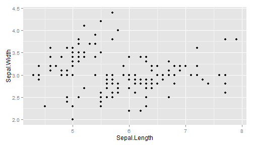

```r
library(ggplot2)
ggplot(data = iris, aes(x = Sepal.Length, y = Sepal.Width)) + geom_point()
```

### 3.3 기초 구조의 이해

```
myplot <- ggplot(data = iris, aes(x = Sepal.Length, y = Sepal.Width))
myplot + geom_point()
```

- 함수 `ggplot` 안에서 데이터와 변수를 정의함
- 일종의 백지 위에 그림을 그릴 대상을 정의한 즉, 데이터 시각화를 위한 셋팅 부분임
- 그 이후 어떤 시각화를 할지의 구체적인 데이터 시각화 컴포넌트 대상, 통계모형, 판넬(panels) 등을 백지 상에 레이어 형태로 그림을 그리는 것임

### 3.4 Further examples

#### 3.4.1 Increase the size of points

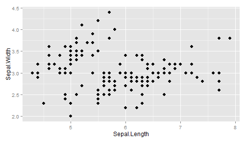

```r
ggplot(data = iris, aes(x = Sepal.Length, y = Sepal.Width)) + geom_point(size = 3)
```

#### 3.4.2 Add some color

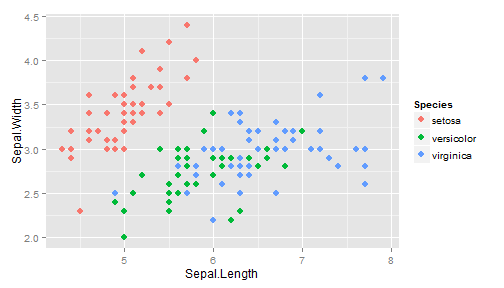

```r
ggplot(iris, aes(Sepal.Length, Sepal.Width, color = Species)) + geom_point(size = 3)
```

#### 3.4.3 Differentiate points by shape

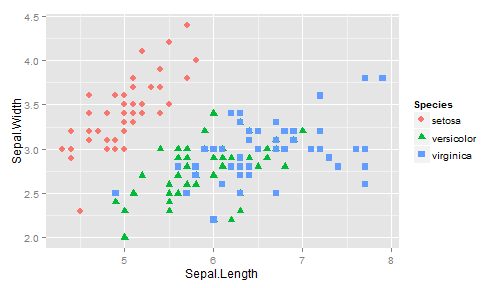

```r
ggplot(iris, aes(Sepal.Length, Sepal.Width, color = Species)) + geom_point(aes(shape = Species),
    size = 3)
```

## 4. 데이터 시각화 컴포넌트들

### 4.1 Box plots

```r
library(MASS)
str(birthwt)
```

```
## 'data.frame':    189 obs. of  10 variables:
##  $ low  : int  0 0 0 0 0 0 0 0 0 0 ...
##  $ age  : int  19 33 20 21 18 21 22 17 29 26 ...
##  $ lwt  : int  182 155 105 108 107 124 118 103 123 113 ...
##  $ race : int  2 3 1 1 1 3 1 3 1 1 ...
##  $ smoke: int  0 0 1 1 1 0 0 0 1 1 ...
##  $ ptl  : int  0 0 0 0 0 0 0 0 0 0 ...
##  $ ht   : int  0 0 0 0 0 0 0 0 0 0 ...
##  $ ui   : int  1 0 0 1 1 0 0 0 0 0 ...
##  $ ftv  : int  0 3 1 2 0 0 1 1 1 0 ...
##  $ bwt  : int  2523 2551 2557 2594 2600 2622 2637 2637 2663 2665 ...
```

```r
head(birthwt)
```

```
##    low age lwt race smoke ptl ht ui ftv  bwt
## 85   0  19 182    2     0   0  0  1   0 2523
## 86   0  33 155    3     0   0  0  0   3 2551
## 87   0  20 105    1     1   0  0  0   1 2557
## 88   0  21 108    1     1   0  0  1   2 2594
## 89   0  18 107    1     1   0  0  1   0 2600
## 91   0  21 124    3     0   0  0  0   0 2622
```

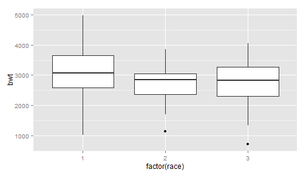

```r
ggplot(birthwt, aes(factor(race), bwt)) + geom_boxplot()
```

### 4.2 Histograms

```r
str(faithful)
```

```
## 'data.frame':    272 obs. of  2 variables:
##  $ eruptions: num  3.6 1.8 3.33 2.28 4.53 ...
##  $ waiting  : num  79 54 74 62 85 55 88 85 51 85 ...
```

```r
head(faithful)
```

```
##   eruptions waiting
## 1     3.600      79
## 2     1.800      54
## 3     3.333      74
## 4     2.283      62
## 5     4.533      85
## 6     2.883      55
```

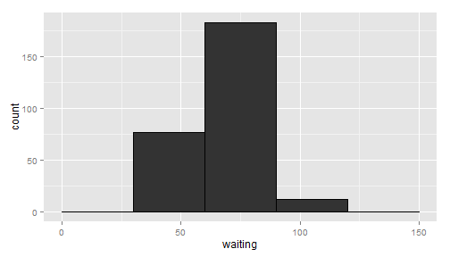

```r
h <- ggplot(faithful, aes(x = waiting))
h + geom_histogram(binwidth = 30, colour = "black")
```

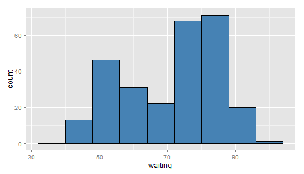

```r
h <- ggplot(faithful, aes(x = waiting))
h + geom_histogram(binwidth = 8, fill = "steelblue", colour = "black")
```

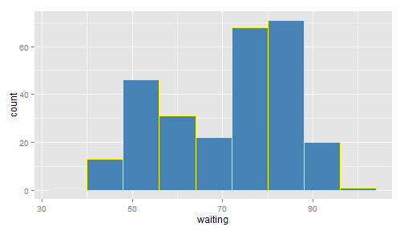

```r
h <- ggplot(faithful, aes(x = waiting))
h + geom_histogram(binwidth = 8, fill = "steelblue", colour = "yellow")
```

### 4.3 Line plots

```r
climate <- read.csv("climate.csv", header = T)
```

[output not shown]

```r
str(climate)
```

[output not shown]

```r
head(climate)
```

[output not shown]

```r
ggplot(climate, aes(Year, Anomaly10y)) + geom_line()
```

[output not shown]

```r
dfn <- read.table(header = T, text = "\nsupp dose length\n  OJ  0.5  13.23\n  OJ  1.0  22.70\n  OJ  2.0  26.06\n  VC  0.5   7.98\n  VC  1.0  16.77\n  VC  2.0  26.14\n")

dfn
```

```
##   supp dose length
## 1   OJ  0.5  13.23
## 2   OJ  1.0  22.70
## 3   OJ  2.0  26.06
## 4   VC  0.5   7.98
## 5   VC  1.0  16.77
## 6   VC  2.0  26.14
```

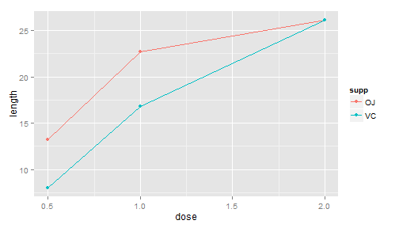

```r
ggplot(data = dfn, aes(x = dose, y = length, group = supp, colour = supp)) +
    geom_line() + geom_point()
```

```r
ggplot(climate, aes(Year, Anomaly10y)) + geom_ribbon(aes(ymin = Anomaly10y -
    Unc10y, ymax = Anomaly10y + Unc10y), fill = "blue", alpha = 0.1) + geom_line(color = "steelblue")
```

[output not shown]

```r
cplot <- ggplot(climate, aes(Year, Anomaly10y))
```

[output not shown]

```r
cplot <- cplot + geom_line(size = 0.7, color = "black")
```

[output not shown]

```r
cplot <- cplot + geom_line(aes(Year, Anomaly10y + Unc10y), linetype = "dashed",
    size = 0.7, color = "red")
```

[output not shown]

```r
cplot <- cplot + geom_line(aes(Year, Anomaly10y - Unc10y), linetype = "dashed",
    size = 0.7, color = "red")
```

[output not shown]

```r
cplot + theme_gray()
```

[output not shown]

### 4.5 Bar plots

#### 4.5.1 plyr과 reshape

- R에서 매우 유용한 두 가지 패키지는 다음과 같음
  - **plyr** - `ddply`, `llply`, `join`
  - **reshape** - `melt`, `dcast`, `acast`

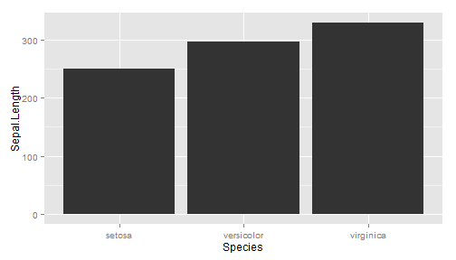

```r
ggplot(iris, aes(Species, Sepal.Length)) + geom_bar(stat = "identity")
```

```r
library(reshape)
df <- melt(iris, id.vars = "Species")
df
```

```
##        Species     variable value
## 1       setosa Sepal.Length   5.1
## 2       setosa Sepal.Length   4.9
## 3       setosa Sepal.Length   4.7
## 4       setosa Sepal.Length   4.6
## 5       setosa Sepal.Length   5.0
## 6       setosa Sepal.Length   5.4
## 7       setosa Sepal.Length   4.6
## 8       setosa Sepal.Length   5.0
## 9       setosa Sepal.Length   4.4
## 10      setosa Sepal.Length   4.9
## 11      setosa Sepal.Length   5.4
## 12      setosa Sepal.Length   4.8
## 13      setosa Sepal.Length   4.8
## 14      setosa Sepal.Length   4.3
```

[output cut: 586 more lines]

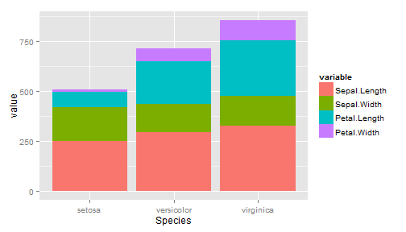

```r
ggplot(df, aes(Species, value, fill = variable)) + geom_bar(stat = "identity")
```

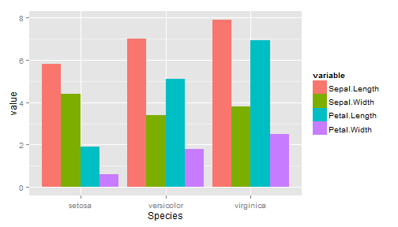

```r
ggplot(df, aes(Species, value, fill = variable)) + geom_bar(stat = "identity",
    position = "dodge")
```

#### 4.5.2 Bar graph 기본

- Bar plots를 그리는데 y축이 해당 x-축 값에 대한 count와 column의 값으로 표현되는 방법이 있음

| x축 | y축 값의 높이 | 데이터 시각화 방법 |
| --- | --- | --- |
| 연속형(numeric) | Count | Histogram |
| 이산형(factor) | Count | Bar plot |
| 연속형(numeric) | Value | Bar plot |
| 이산형(factor) | Value | Bar plot |

```r
df <- data.frame(time = factor(c("Lunch", "Dinner"), levels = c("Lunch", "Dinner")),
    total_bill = c(14.89, 17.23))
df
```

```
##     time total_bill
## 1  Lunch      14.89
## 2 Dinner      17.23
```

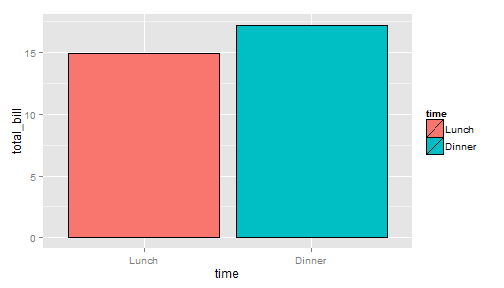

```r
# Add a black outline
ggplot(data = df, aes(x = time, y = total_bill, fill = time)) + geom_bar(colour = "black",
    stat = "identity")
```

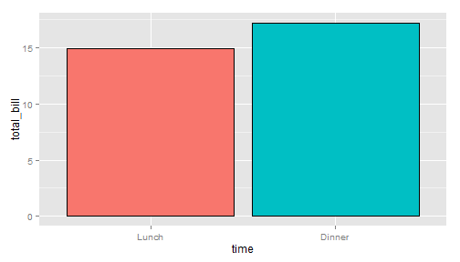

```r
# No legend, since the information is redundant
ggplot(data = df, aes(x = time, y = total_bill, fill = time)) + geom_bar(colour = "black",
    stat = "identity") + guides(fill = FALSE)
```

```r
library(reshape2)
str(tips)
```

```
## 'data.frame':    244 obs. of  7 variables:
##  $ total_bill: num  17 10.3 21 23.7 24.6 ...
##  $ tip       : num  1.01 1.66 3.5 3.31 3.61 4.71 2 3.12 1.96 3.23 ...
##  $ sex       : Factor w/ 2 levels "Female","Male": 1 2 2 2 1 2 2 2 2 2 ...
##  $ smoker    : Factor w/ 2 levels "No","Yes": 1 1 1 1 1 1 1 1 1 1 ...
##  $ day       : Factor w/ 4 levels "Fri","Sat","Sun",..: 3 3 3 3 3 3 3 3 3 3 ...
##  $ time      : Factor w/ 2 levels "Dinner","Lunch": 1 1 1 1 1 1 1 1 1 1 ...
##  $ size      : int  2 3 3 2 4 4 2 4 2 2 ...
```

```r
head(tips)
```

```
##   total_bill  tip    sex smoker day   time size
## 1      16.99 1.01 Female     No Sun Dinner    2
## 2      10.34 1.66   Male     No Sun Dinner    3
## 3      21.01 3.50   Male     No Sun Dinner    3
## 4      23.68 3.31   Male     No Sun Dinner    2
## 5      24.59 3.61 Female     No Sun Dinner    4
## 6      25.29 4.71   Male     No Sun Dinner    4
```

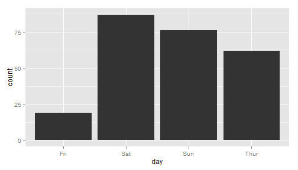

```r
# Bar graph of counts
ggplot(data = tips, aes(x = day)) + geom_bar(stat = "bin")
```

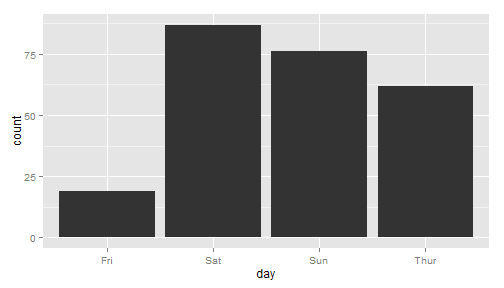

```r
# Equivalent to this, since stat='bin' is the default:
ggplot(data = tips, aes(x = day)) + geom_bar()
```

#### 4.5.3 More examples

```r
df1 <- data.frame(sex = factor(c("Female", "Female", "Male", "Male")), time = factor(c("Lunch",
    "Dinner", "Lunch", "Dinner"), levels = c("Lunch", "Dinner")), total_bill = c(13.53,
    16.81, 16.24, 17.42))
df1
```

```
##      sex   time total_bill
## 1 Female  Lunch      13.53
## 2 Female Dinner      16.81
## 3   Male  Lunch      16.24
## 4   Male Dinner      17.42
```

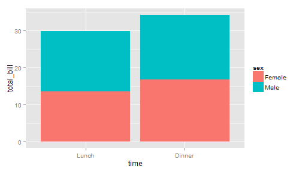

```r
# Stacked bar graph -- this is probably not what you want
ggplot(data = df1, aes(x = time, y = total_bill, fill = sex)) + geom_bar(stat = "identity")
```

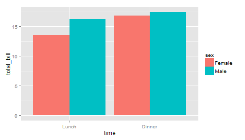

```r
# Bar graph, time on x-axis, color fill grouped by sex -- use
# position_dodge()
ggplot(data = df1, aes(x = time, y = total_bill, fill = sex)) + geom_bar(stat = "identity",
    position = position_dodge())
```

```r
d2 <- diamonds[sample(1:dim(diamonds)[1], 1000), ]
head(d2)
```

```
##       carat       cut color clarity depth table price    x    y    z
## 43320  0.51   Premium     E     SI1  62.9    57  1402 5.11 5.06 3.20
## 43200  0.53 Very Good     E     SI1  61.6    58  1395 5.19 5.23 3.21
## 37731  0.53 Very Good     J     VS2  62.7    56   996 5.15 5.18 3.24
## 22760  1.50     Ideal     E     SI1  62.6    56 10777 7.27 7.30 4.56
## 17810  1.23 Very Good     H     VS2  60.2    63  7177 6.95 6.91 4.17
## 9275   1.04 Very Good     H     SI1  62.8    57  4564 6.44 6.48 4.06
```

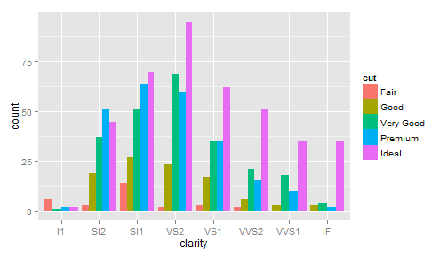

```r
ggplot(d2, aes(clarity, fill = cut)) + geom_bar(position = "dodge", stat = "bin") +
    theme_gray()
```

```r
climate$sign <- ifelse(climate$Anomaly10y < 0, FALSE, TRUE)
```

[output not shown]

```r
# or as simple as clim$sign <- climate$Anomaly10y < 0
head(climate)
```

[output not shown]

```r
ggplot(climate, aes(Year, Anomaly10y)) + geom_bar(stat = "identity", aes(fill = sign)) +
    theme_gray()
```

[output not shown]

#### 4.5.4 Line plots와의 관계

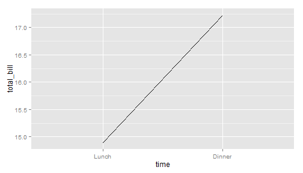

```r
# Basic line graph. These both have the same result.
ggplot(data = df, aes(x = time, y = total_bill, group = 1)) + geom_line()
```

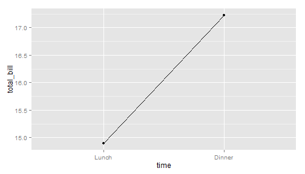

```r
# Add points
ggplot(data = df, aes(x = time, y = total_bill, group = 1)) + geom_line() +
    geom_point()
```

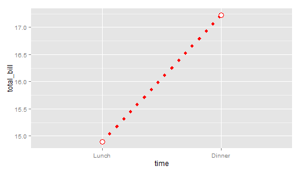

```r
# Change color of both line and points Change line type and point type,
# and use thicker line and larger points Change points to circles with
# white fill
ggplot(data = df, aes(x = time, y = total_bill, group = 1)) + geom_line(colour = "red",
    linetype = "dotted", size = 1.5) + geom_point(colour = "red", size = 4,
    shape = 21, fill = "white")
```

### 4.6 Density plots

```r
head(faithful)
```

```
##   eruptions waiting
## 1     3.600      79
## 2     1.800      54
## 3     3.333      74
## 4     2.283      62
## 5     4.533      85
## 6     2.883      55
```

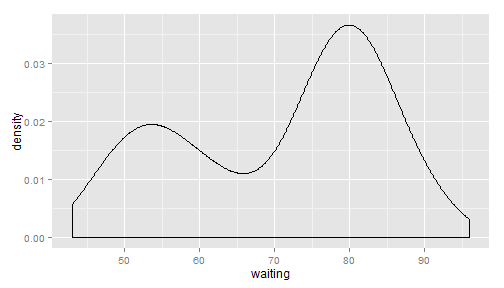

```r
ggplot(faithful, aes(waiting)) + geom_density()
```

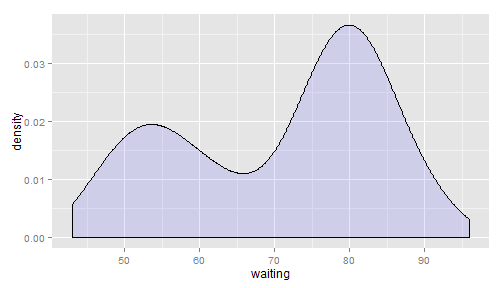

```r
ggplot(faithful, aes(waiting)) + geom_density(fill = "blue", alpha = 0.1)
```

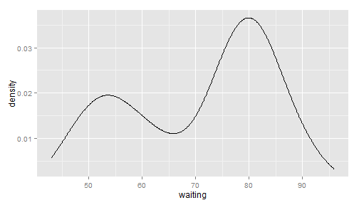

```r
ggplot(faithful, aes(waiting)) + geom_line(stat = "density")
```

### 4.7 Polar coordinates

```r
head(mtcars)
```

```
##                    mpg cyl disp  hp drat    wt  qsec vs am gear carb
## Mazda RX4         21.0   6  160 110 3.90 2.620 16.46  0  1    4    4
## Mazda RX4 Wag     21.0   6  160 110 3.90 2.875 17.02  0  1    4    4
## Datsun 710        22.8   4  108  93 3.85 2.320 18.61  1  1    4    1
## Hornet 4 Drive    21.4   6  258 110 3.08 3.215 19.44  1  0    3    1
## Hornet Sportabout 18.7   8  360 175 3.15 3.440 17.02  0  0    3    2
## Valiant           18.1   6  225 105 2.76 3.460 20.22  1  0    3    1
```

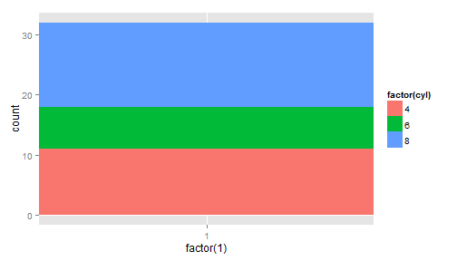

```r
p.tmp <- ggplot(mtcars, aes(x = factor(1), fill = factor(cyl))) + geom_bar(width = 1)
p.tmp
```

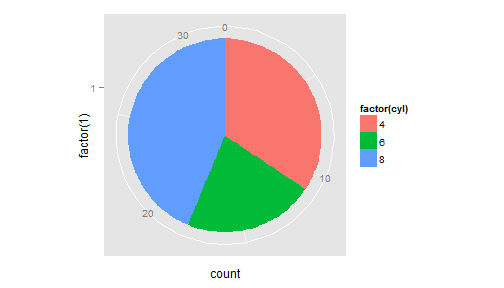

```r
p.tmp + coord_polar(theta = "y")
```

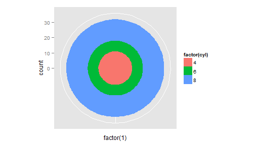

```r
p.tmp + coord_polar(theta = "x")
```

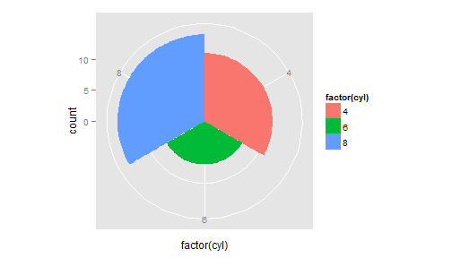

```r
ggplot(mtcars, aes(factor(cyl), fill = factor(cyl))) + geom_bar(width = 1) +
    coord_polar()
```

[figure not shown]

```r
# Hadley's favourite pie chart
df <- data.frame(variable = c("resembles", "does not resemble"), value = c(80,
    20))
ggplot(df, aes(x = "", y = value, fill = variable)) + geom_bar(width = 1, stat = "identity") +
    scale_fill_manual(values = c("red", "yellow")) + coord_polar("y", start = pi/3) +
    labs(title = "Pac man")
```

## 5. 데이터의 변형 - reshape를 중심으로

- **reshape** 패키지는 데이터 형태의 재배열, coningency table 생성, 데이터 summarising등을 할 수 있게 해줌
- 사용하는 data frame은 **reshape** 패키지 내의 *smiths* 데이터를 사용함
- 본 내용은 [Journal of Stiatical Software](http://www.jstatsoft.org/v21/i12/paper)에 게재된 내용을 [차 용](http://rpubs.com/chayong/reshape)이 정리한 것을 바탕으로 작성함

### 5.1 `melt()`

- `melt()` function을 사용할 때 **identifier**(이하 id)와 **measured variable**을 구분하는 것은 매우 중요함
- 즉, 어떤 변수가 **measured variable**인지 **id variable**인지 알아야 할 필요가 있음
  - **identifier**(id variable) : 보통 이산형이나 고정값. 특별히 지정해 주지 않으면 factor or integer column을 id variable로 인식한다.
  - **measured variable** : 측정 대상이 되는 변수. 쉽게 말하면 categorize되는 변수
- `melt()` 는 **id variable**을 기준으로 하고 **measured variable**를 categorize하여 `variable`이라는 새로운 column을 생성하고 `value`라는 column에 Variable에 해당하는 값들을 넣어 주어 새로이 Data frame을 만들어 줌

```r
smiths
```

```
##      subject time age weight height
## 1 John Smith    1  33     90   1.87
## 2 Mary Smith    1  NA     NA   1.54
```

- 위의 데이터를 `melt()`를 이용하여 변환되는 것을 살펴봄

```r
melt(smiths, id = c("subject", "time"), measured = c("age", "weight", "height"))
```

```
##      subject time variable value
## 1 John Smith    1      age 33.00
## 2 Mary Smith    1      age    NA
## 3 John Smith    1   weight 90.00
## 4 Mary Smith    1   weight    NA
## 5 John Smith    1   height  1.87
## 6 Mary Smith    1   height  1.54
```

- `id`로 지정된 변수에 대하여 `measured`에 해당하는 변수들에 대하여 melted된 데이터에는
  - `variable`에는 해당 변수이름이 값으로 채워지고
  - `value`라는 변수에는 `variable`에 해당하는 변수의 값이 채워짐

```r
melt(smiths, id = c("subject", "time"))
```

```
##      subject time variable value
## 1 John Smith    1      age 33.00
## 2 Mary Smith    1      age    NA
## 3 John Smith    1   weight 90.00
## 4 Mary Smith    1   weight    NA
## 5 John Smith    1   height  1.87
## 6 Mary Smith    1   height  1.54
```

- `measured`를 지정하지 않으면 data frame 내에 `id` 이외의 모든 다른 변수들이 사용됨

```r
melt(smiths, id = 1:2, na.rm = T)
```

```
##      subject time variable value
## 1 John Smith    1      age 33.00
## 2 John Smith    1   weight 90.00
## 3 John Smith    1   height  1.87
## 4 Mary Smith    1   height  1.54
```

- 옵션 `na.rm=T` 은 melted된 **value** 가 NA인 케이스를 remove함을 의미함

### 5.2 `cast()`

- `cast()`는 `melt()` function을 적용한 data frame(혹은 object)을 사용자가 원하는 모양으로 재배열을 할 수 있게 해주는 함수임

[output not shown]

- `melt()`에서 melting한 데이터를 중심으로 살펴봄

```r
smithsm <- melt(smiths, id = 1:2)  # smithsm : molten data 'smiths'
smithsm
```

```
##      subject time variable value
## 1 John Smith    1      age 33.00
## 2 Mary Smith    1      age    NA
## 3 John Smith    1   weight 90.00
## 4 Mary Smith    1   weight    NA
## 5 John Smith    1   height  1.87
## 6 Mary Smith    1   height  1.54
```

```r
cast(smithsm, subject + time ~ variable)
```

```
##      subject time age weight height
## 1 John Smith    1  33     90   1.87
## 2 Mary Smith    1  NA     NA   1.54
```

```r
cast(smithsm, ... ~ subject, sum, margins = c("grand_row", "grand_col"))
```

```
##    time variable John Smith Mary Smith (all)
## 1     1      age      33.00         NA    NA
## 2     1   weight      90.00         NA    NA
## 3     1   height       1.87       1.54  3.41
## 4 (all)    (all)     124.87         NA    NA
```

- `subject`를 제외한 `time`과 `variable`에 대하여 `subject`의 값을 변수명으로 펼쳐 sum을 계산하라는 의미임
- `margin`은 행, 열방향의 합을 구하라는 것임

### 5.3 `cast()` example

```r
# Air quality example
names(airquality) <- tolower(names(airquality))
head(airquality)
```

```
##   ozone solar.r wind temp month day
## 1    41     190  7.4   67     5   1
## 2    36     118  8.0   72     5   2
## 3    12     149 12.6   74     5   3
## 4    18     313 11.5   62     5   4
## 5    NA      NA 14.3   56     5   5
## 6    28      NA 14.9   66     5   6
```

```r
aqm <- melt(airquality, id = c("month", "day"), na.rm = TRUE)
head(aqm)
```

```
##   month day variable value
## 1     5   1    ozone    41
## 2     5   2    ozone    36
## 3     5   3    ozone    12
## 4     5   4    ozone    18
## 5     5   6    ozone    28
## 6     5   7    ozone    23
```

```r
cast(aqm, day ~ month ~ variable)
```

```
## , , variable = ozone
##
##     month
## day    5  6   7   8  9
##   1   41 NA 135  39 96
##   2   36 NA  49   9 78
##   3   12 NA  32  16 73
##   4   18 NA  NA  78 91
##   5   NA NA  64  35 47
##   6   28 NA  40  66 32
##   7   23 29  77 122 20
##   8   19 NA  97  89 23
##   9    8 71  97 110 21
##   10  NA 39  85  NA 24
##   11   7 NA  NA  NA 44
```

[output cut: 128 more lines]

```r
cast(aqm, month ~ variable, mean)
```

```
##   month ozone solar.r   wind  temp
## 1     5 23.62   181.3 11.623 65.55
## 2     6 29.44   190.2 10.267 79.10
## 3     7 59.12   216.5  8.942 83.90
## 4     8 59.96   171.9  8.794 83.97
## 5     9 31.45   167.4 10.180 76.90
```

```r
cast(aqm, month ~ . | variable, mean)
```

```
## $ozone
##   month (all)
## 1     5 23.62
## 2     6 29.44
## 3     7 59.12
## 4     8 59.96
## 5     9 31.45
##
## $solar.r
##   month (all)
## 1     5 181.3
## 2     6 190.2
## 3     7 216.5
## 4     8 171.9
## 5     9 167.4
##
## $wind
##   month  (all)
## 1     5 11.623
## 2     6 10.267
## 3     7  8.942
## 4     8  8.794
## 5     9 10.180
##
## $temp
##   month (all)
## 1     5 65.55
## 2     6 79.10
## 3     7 83.90
## 4     8 83.97
## 5     9 76.90
```

```r
cast(aqm, month ~ variable, mean, margins = c("grand_row", "grand_col"))
```

```
##   month ozone solar.r   wind  temp (all)
## 1     5 23.62   181.3 11.623 65.55 68.71
## 2     6 29.44   190.2 10.267 79.10 87.38
## 3     7 59.12   216.5  8.942 83.90 93.50
## 4     8 59.96   171.9  8.794 83.97 79.71
## 5     9 31.45   167.4 10.180 76.90 71.83
## 6 (all) 42.13   185.9  9.958 77.88 80.06
```

```r
cast(aqm, day ~ month, mean, subset = variable == "ozone")
```

```
##    day   5   6   7   8   9
## 1    1  41 NaN 135  39  96
## 2    2  36 NaN  49   9  78
## 3    3  12 NaN  32  16  73
## 4    4  18 NaN NaN  78  91
## 5    5 NaN NaN  64  35  47
## 6    6  28 NaN  40  66  32
## 7    7  23  29  77 122  20
## 8    8  19 NaN  97  89  23
## 9    9   8  71  97 110  21
## 10  10 NaN  39  85 NaN  24
## 11  11   7 NaN NaN NaN  44
## 12  12  16 NaN  10  44  21
## 13  13  11  23  27  28  28
## 14  14  14 NaN NaN  65   9
```

[output cut: 17 more lines]

```r
cast(aqm, month ~ variable, range)
```

```
##   month ozone_X1 ozone_X2 solar.r_X1 solar.r_X2 wind_X1 wind_X2 temp_X1
## 1     5        1      115          8        334     5.7    20.1      56
## 2     6       12       71         31        332     1.7    20.7      65
## 3     7        7      135          7        314     4.1    14.9      73
## 4     8        9      168         24        273     2.3    15.5      72
## 5     9        7       96         14        259     2.8    16.6      63
##   temp_X2
## 1      81
## 2      93
## 3      92
## 4      97
## 5      93
```

```r
cast(aqm, month ~ variable + result_variable, range)
```

```
##   month ozone_X1 ozone_X2 solar.r_X1 solar.r_X2 wind_X1 wind_X2 temp_X1
## 1     5        1      115          8        334     5.7    20.1      56
## 2     6       12       71         31        332     1.7    20.7      65
## 3     7        7      135          7        314     4.1    14.9      73
## 4     8        9      168         24        273     2.3    15.5      72
## 5     9        7       96         14        259     2.8    16.6      63
##   temp_X2
## 1      81
## 2      93
## 3      92
## 4      97
## 5      93
```

```r
cast(aqm, variable ~ month ~ result_variable, range)
```

```
## , , result_variable = X1
##
##          month
## variable     5    6    7    8    9
##   ozone    1.0 12.0  7.0  9.0  7.0
##   solar.r  8.0 31.0  7.0 24.0 14.0
##   wind     5.7  1.7  4.1  2.3  2.8
##   temp    56.0 65.0 73.0 72.0 63.0
##
## , , result_variable = X2
##
##          month
## variable      5     6     7     8     9
##   ozone   115.0  71.0 135.0 168.0  96.0
##   solar.r 334.0 332.0 314.0 273.0 259.0
##   wind     20.1  20.7  14.9  15.5  16.6
##   temp     81.0  93.0  92.0  97.0  93.0
```